# Cyclitics Analysis

# Ask - **Navigating Cyclitics Challenge and Objectives**

This chapter will provide context and a clear statement of the business task Cyclistic aims to address.

## Introduction

Welcome to the Cyclistic bike-share analysis case study!

This document shows the results of the Google Data Analytics capstone project on Cyclistic, a bike-sharing company in Chicago. The data source is 64 CSV files of bike trip data from June 2013 to Jan 2024. The tools and methods are Excel, R and Tableau. The main findings and recommendations are based on the key business questions and metrics of Cyclistic. The audience is the executive team of Cyclistic.

## Background of Cyclitics

In 2016, Cyclistic launched a successful bike-share offering. Since then, the program has grown to a fleet of 5,824 bicycles that are geo tracked and locked into a network of 692 stations across Chicago. The bikes can be unlocked from one station and returned to any other station in the system anytime.

Until now, Cyclistic’s marketing strategy relied on building general awareness and appealing to broad consumer segments. One approach that helped make these things possible was the flexibility of its pricing plans: single-ride passes, full-day passes, and annual memberships. Customers who purchase single-ride or full-day passes are referred to as casual riders. Customers who purchase annual memberships are Cyclistic members.

Cyclistic’s finance analysts have concluded that annual members are much more profitable than casual riders. Although the pricing flexibility helps Cyclistic attract more customers, Moreno believes that maximizing the number of annual members will be key to future growth. Rather than creating a marketing campaign that targets all-new customers, Moreno believes there is a solid opportunity to convert casual riders into members. She notes that casual riders are already aware of the Cyclistic program and have chosen Cyclistic for their mobility needs.

Moreno has set a clear goal: Design marketing strategies aimed at converting casual riders into annual members. In order to do that, however, the team needs to better understand how annual members and casual riders differ, why casual riders would buy a membership, and how digital media could affect their marketing tactics. Moreno and her team are interested in analyzing the Cyclistic historical bike trip data to identify trends.

## Characters and teams

**Cyclistic**: A bike-share program that features more than 5,800 bicycles and 600 docking stations. Cyclistic sets itself apart by also offering reclining bikes, hand tricycles, and cargo bikes, making bike-share more inclusive to people with disabilities and riders who can’t use a standard two-wheeled bike. The majority of riders opt for traditional bikes; about 8% of riders use the assistive options. Cyclistic users are more likely to ride for leisure, but about 30% use the bikes to commute to work each day.

**Lily Moreno**: The director of marketing and your manager. Moreno is responsible for the development of campaigns and initiatives to promote the bike-share program. These may include email, social media, and other channels.

**Cyclistic marketing analytics team**: A team of data analysts who are responsible for collecting, analyzing, and reporting data that helps guide Cyclistic marketing strategy. You joined this team six months ago and have been busy learning about Cyclistic’s mission and business goals—as well as how you, as a junior data analyst, can help Cyclistic achieve them.

**Cyclistic executive team**: The notoriously detail-oriented executive team will decide whether to approve the recommended marketing program.

## Clear Articulation of the Business Task

The director of marketing believes the company’s future success depends on maximizing the number of annual memberships. Therefore, your team wants to understand **how casual riders and annual members use Cyclistic bikes differently** using the most recent data. From these insights, your team will design a new marketing strategy to convert casual riders into annual members. But first, Cyclistic executives must approve your recommendations, so they must be backed up with compelling data insights and professional data visualizations.

# Prepare - *Unveiling the Data Landscape: Sources, Types, and Significance*

Detailing the various data sources used in the analysis, including their nature and relevance to the business task.

## Tools We Utilize in the Project:

**Excel:**

We rely on Excel for the project’s initial stages, focusing on data exploration and basic analysis. Its user-friendly interface enables us to quickly glean insights and create preliminary visualizations, providing an initial grasp of the dataset.

**R:**

In the more advanced phases, we turn to R for critical tasks such as data merging, cleaning, transformation, and in-depth analysis. Leveraging its robust statistical capabilities and extensive libraries allows us to conduct comprehensive exploration and visualization, ensuring a thorough understanding of the data.

**Tableau:**

Strategically, we employ Tableau for crafting advanced visualizations tailored to address specific questions. Its dynamic and interactive features enhance the presentation of complex patterns, offering a deeper layer of exploration for stakeholders seeking nuanced insights.

**PowerPoint:**

PowerPoint becomes the final destination for presenting our key findings and insights. It transforms analytical results into a visually appealing and compelling narrative. PowerPoint’s capabilities allow us to create engaging presentations, ensuring effective communication of complex analyses to diverse audiences.

By harnessing the strengths of Excel, R, Tableau, and PowerPoint, this comprehensive toolset ensures a seamless workflow from initial data exploration to advanced analysis, sophisticated visualization, and impactful presentation.

## All Provided Datasets (2013-2024)

### Where is the data located?

The data is publicly available on this link: [https://Cyclistic-tripdata.s3.amazonaws.com/index.html](https://divvy-tripdata.s3.amazonaws.com/index.html). This link contains monthly trip data files in CSV format from June 2013 to Jan 2024. The data is owned by the City of Chicago and licensed by Bikeshare, the operator of the Cyclistic bicycle sharing service.

### How is the data organized?

The data consists of two types of files: **Trip data** and **Station data**. The trip data contains information about each bike trip taken by Cyclistic users, such as trip id, start time, end time, bike id, and trip duration. The station data contains information about each bike station in the Cyclistic network, such as name, latitude, longitude, capacity, and online date.

The data is divided into 64 folders, each containing data for a specific period of time. The folder names indicate the year, the month, or the quarter of the data. For example, the folder “Cyclistic_Stations_Trips_2014_Q1Q2” contains data for the first and second quarters of 2014, and the folder “202312-Cyclistic-tripdata” contains data for December 2023.

Each folder has one or two CSV files (trips and stations), some containing data for one month. For example, the file “202211-Cyclistic-tripdata.csv” contains data for November 2022, and others like “Cyclistic_Trips_2017_Q1.csv” contain data for the first quarter of 2017.

The station data is not available for all the folders. Only the folders that contain data for 2013, 2014, and 2015 have a separate CSV file for the station data. The station data for the other years is not provided in the data source.

The Trips data is chronologically organized by minute, hour, day, month and year, with each observation refers to a unique trip. Each trip has the following features:

1. **trip_id:** Integer (unique identifier for each trip
2. **start_time:** DateTime (the date and time when the trip started)
3. **end_time:** DateTime (the date and time when the trip ended)
4. **bikeid:** Integer (unique identifier for each bike)
5. **tripduration:** Integer (duration of the trip in seconds)
6. **from_station_id:** Integer (ID of the station where the trip originated)
7. **from_station_name:** String (name of the station where the trip originated)
8. **to_station_id:** Integer (ID of the station where the trip ended)
9. **to_station_name:** String (name of the station where the trip ended)
10. **usertype:** String (type of user, either “Subscriber” or “Customer”)
11. **gender:** String (gender of the user, either “Male”, “Female”, or blank)
12. **birthyear:** Integer (birth year of the user, or blank)
13. **rideable_type:** String (type of bike, either “classic” or “electric”)
14. **start_lat:** Float (latitude of the start location)
15. **start_lng:** Float (longitude of the start location)
16. **end_lat:** Float (latitude of the end location)
17. **end_lng:** Float (longitude of the end location)

**Note**: Some of these features may not be provided in some tables at all, depending on the year and the month of the data. The features that may be missing are: bikeid, rideable_type, tripduration, start_lat, start_lng, end_lat, end_lng, gender, and birthyear.

In the other hand, The Station data is geographically organized by latitude and longitude, with each row containing information for a specific station. Each station has the following features:

1. **name**: the name of the station
2. **latitude**: the latitude of the station location
3. **longitude**: the longitude of the station location
4. **dpcapacity**: the number of total docks at each station as of the date of the file online
5. **date**: the date the station went live in the system

### Addressing Licensing, Privacy, Security, and Accessibility

To address licensing, we are following the terms and conditions of the Data License Agreement provided by Bikeshare on this link: [https://Cyclisticbikes.com/data-license-agreement](https://divvybikes.com/data-license-agreement). This agreement grants us a non-exclusive, royalty-free, limited, perpetual license to access, reproduce, analyze, copy, modify, distribute in our product or service and use the data for any lawful purpose. However, it also prohibits us from doing certain things, such as using the data in an unlawful manner, hosting or selling the data as a stand-alone dataset, accessing the data by unauthorized means, circumventing any access restrictions, using data mining or extraction methods, attempting to correlate the data with personal information of users, and stating or implying that we are affiliated or endorsed by Bikeshare. We are also respecting the trademarks and trade names of Bikeshare, the City of Chicago, and any sponsor of the Cyclistic service, and not using them without written permission. For the purpose of this case study, we are referring to the company as Cyclistics.

To address privacy, we are protecting the personal information of Cyclistic users, such as their genders and birth years, and not disclosing or sharing it with anyone. We are also not attempting to identify or correlate the users with their names, addresses, or other information. We are only using the data for analytical purposes and not for any malicious or harmful purposes.

To address security, we are storing the data in a secure location, such as a cloud-based platform or a password-protected device, and not exposing it to unauthorized access or tampering. We are also using encryption and authentication methods to ensure the integrity and confidentiality of the data.

To address accessibility, we are making the data available and understandable to our intended audience, such as our stakeholders, clients, or customers, and not restricting or limiting their access to the data. We are also using appropriate formats and tools to present and visualize the data, such as tables, charts, graphs, or dashboards, and providing clear and concise explanations and interpretations of the data.

1. **Licensing:**
   - The data used in this analysis is sourced from the City of Chicago’s Divvy bicycle sharing service, and the licensing agreement between Bikeshare and the City on this link: [https://Cyclisticbikes.com/data-license-agreement](https://divvybikes.com/data-license-agreement). explicitly grants a non-exclusive, royalty-free, limited, perpetual license for various uses.
2. **Privacy:**
   - The data used does not include any personal information about Cyclitics bike-share users, aligning with the privacy provisions outlined in the license agreement and we confirmed that any sensitive or personally identifiable information has been redacted or excluded from the datasets used in the analysis.
3. **Security:**
   - Given the public and non-sensitive nature of the data, and the restrictions in the license agreement, security risks are inherently low.
4. **Accessibility**
   - Accessibility is facilitated by the public availability of the data as permitted by the license agreement, ensuring transparency and collaboration across teams involved in the analysis. Also, we are using appropriate formats and tools to present and visualize the data, such as tables, charts, graphs, or presentations, and providing clear and concise explanations and interpretations of the data.

### Issues with Bias or Credibility (ROCCC)

ROCCC stands for Reliable, Original, Comprehensive, Current, and Cited. It is a framework for evaluating the quality and credibility of data sources.

1. **Reliable**: The data is reliable if it is consistent, accurate, and trustworthy. To assess the reliability of the data, I would check the following:
   - The data source: The data is owned by the City of Chicago and licensed by Bikeshare, the operator of the Cyclitics bicycle sharing service. These are reputable and official entities that have an interest in providing accurate and transparent data to the public. Therefore, the data source is reliable.
   - The data collection method: The data is collected automatically by the Cyclitics system, which records the details of each bike trip taken by the users. The data collection method is reliable, as it minimizes the possibility of human error or manipulation.
   - The data quality: The data is mostly complete and consistent, with only a few missing or blank values. The data quality is reliable, as it does not have major errors or anomalies that could affect the analysis.
2. **Original**: The data is original if it is the primary source of information, and not derived or copied from another source. To assess the originality of the data, I would check the following:
   - The data provenance: The data is directly provided by the City of Chicago and Bikeshare, which are the original owners and providers of the data. The data provenance is original, as it does not involve any intermediaries or third parties that could alter or modify the data.
   - The data format: The data is provided in CSV format, which is a common and standard format for storing and sharing tabular data. The data format is original, as it does not require any conversion or transformation that could affect the data integrity.
3. **Comprehensive**: The data is comprehensive if it covers all the relevant aspects and dimensions of the topic or question. To assess the comprehensiveness of the data, I would check the following:
   - The data scope: The data covers all the bike trips taken by Cyclistic users from June 2013 to Jan 2024, in the city of Chicago and its surrounding areas. The data scope is comprehensive, as it provides a large and diverse sample of the bike-sharing service usage and behavior.
   - The data features: The data contains various features that describe each bike trip, such as the trip_id, start_time, end_time, bike_id, trip_duration, from_station_name, to_station_name, user_type, rideable_type, start_lat, start_lng, end_lat, and end_lng. The data features are comprehensive, as they provide a rich and detailed information about the bike trips and the users (but not user personal information)
4. **Current**: The data is current if it is up-to-date and relevant to the present time. To assess the currency of the data, I would check the following:
   - The data timeliness: The data is updated twice per year, and the latest available data is from Jan 2024. The data timeliness is current, as it reflects the most recent status and trends of the bike-sharing service.
   - The data frequency: In the last 3 year, the data is provided monthly, which is a reasonable and appropriate frequency for the bike-sharing service. The data frequency is current, as it allows for timely and periodic analysis of the data.
5. **Cited**: The data is cited if it provides the source and the license of the data, and acknowledges the rights and responsibilities of the data users and providers. To assess the citation of the data, I would check the following:
   - The data source: The data source is clearly stated and linked on the data website, which is https://Cyclistic-tripdata.s3.amazonaws.com/index.html. The data source is cited, as it gives credit and recognition to the data owners and providers.
   - The data license: The data license is also clearly stated and linked on the data website, which is [https://Cyclisticbikes.com/data-license-agreement](https://divvybikes.com/data-license-agreement). The data license is cited, as it specifies the terms and conditions ofthe data usage and sharing

## Subset Relevant to The Case Study

### Data Time-Frame

In order to answer the business question of how annual members and casual riders use Cyclistic bikes differently, we will focus on the data from the last 12 months (2023 Q1 to 2023 Q4). This data is relevant and sufficient to capture the seasonal and contextual variations in the bike usage patterns. We will exclude the data from 2013 to 2022, as it is not necessary for our analysis and may introduce noise or bias.

### Relevance to the Business Task

This data subset provides features like: ride_id, rideable_type, started_at, ended_at, start_station_name, start_station_id, end_station_name, end_station_id, start_lat, start_lng, end_lat, end_lng and member_casual helps us answer our question, which is: How do annual members and casual riders use Cyclistics bikes differently in various ways

By analyzing the data, we can compare and contrast the behavior and preferences of the two user types, such as:

1. How often they use Cyclistics bikes, and how long their trips are.
2. When they use Cyclistics bikes, and how seasonality or weather affects their usage.
3. they use Cyclistics bikes, and which stations or routes are most popular or least popular among them.
4. Why they use Cyclistics bikes, and what are their motivations or goals for using them.

### Problems with the Data

There are some minor problems with the data that could affect the analysis and the results, but they can be fixed or avoided with some data cleaning and preparation steps. These problems are related to the data structure, the data completeness, and the data currency. Here are some examples of the problems:

- **Data currency:** The data for the last three years (since 2020) missed some of the information that was there in previous data sets, such as bikeid, gender, and birth year. This could lead to the gender and age group insight to be outdated or inaccurate, as the data may not reflect the current or the recent status and trends of the bike-sharing service or the users. This could also affect the comparability or the consistency of the data, as the data from different years may have different structures or features.
- **Data types mismatch:** Another issue observed in the dataset is the presence of data types mismatch. For example, certain columns like ‘started_at’ and ‘ended_at’ are currently stored as character strings instead of datetime objects. This discrepancy can hinder accurate time-based analysis, as operations such as sorting or calculating time intervals may not be performed correctly. Addressing this issue through proper conversion of data types will contribute to the accuracy and reliability of temporal analyses.

# Process - **Ensuring Data Accuracy and Relevance**

Documenting the steps taken to clean and manipulate the data to ensure its accuracy and relevance to the analysis.

## Approach

We’re working with data from 2023, split into 12 monthly files. Luckily, these files share identical Structure, including the available features, their names, their data types, and their possible values. This enables the seamless merging of all CSV files into a single, comprehensive dataset. Managing and cleaning a unified dataset proves more efficient than addressing each monthly file in isolation

Once merged, our data cleaning process encompasses addressing data types, handling missing values, resolving duplicates, identifying outliers, and rectifying any other potential errors encountered during the merging process. Additionally, we will introduce new features essential for addressing the core business question.

This holistic approach ensures the data is not only consolidated but also refined for robust analysis and insightful decision-making.

## **Data Integration: Unifying Multiple Files**

Using R, we will merge all the 12 csv into a single one.

I moved all the necessary CSV files into one folder named “Subset_2023”. Now I’ll merge them using the dplyr’s functions. But first, I must change the working directory:

```r
# Save the path string in a variable
project_path <- "D:/cycliticsBikeShareAnalysis"

# Set the working directory to the location of the .Rmd file
setwd(here::here(project_path))

# Specify the full path to the "Subset_2023" folder
data_folder <- here::here(project_path, "Subset_2023")

# List all CSV files in the "Subset_2023" folder
file_names <- list.files(data_folder, pattern = "\\.csv$", full.names = TRUE)

# Read and merge CSV files
merged_data <- lapply(file_names, read.csv) %>%
  bind_rows()

# Write the merged dataset to a new CSV file
write.csv(merged_data, here::here(project_path, "Merged_Data_2023.csv"), row.names = FALSE)
```

```r
merged_data <- read.csv("D:/cycliticsBikeShareAnalysis/Merged_Data_2023.csv")
```

After running the code, we check the structure and summary of the merged data set to ensure everything is in order

```r
str(merged_data)
```

```
## 'data.frame':    5719877 obs. of  13 variables:
##  $ ride_id           : chr  "F96D5A74A3E41399" "13CB7EB698CEDB88" "BD88A2E670661CE5" "C90792D034FED968" ...
##  $ rideable_type     : chr  "electric_bike" "classic_bike" "electric_bike" "classic_bike" ...
##  $ started_at        : chr  "2023-01-21 20:05:42" "2023-01-10 15:37:36" "2023-01-02 07:51:57" "2023-01-22 10:52:58" ...
##  $ ended_at          : chr  "2023-01-21 20:16:33" "2023-01-10 15:46:05" "2023-01-02 08:05:11" "2023-01-22 11:01:44" ...
##  $ start_station_name: chr  "Lincoln Ave & Fullerton Ave" "Kimbark Ave & 53rd St" "Western Ave & Lunt Ave" "Kimbark Ave & 53rd St" ...
##  $ start_station_id  : chr  "TA1309000058" "TA1309000037" "RP-005" "TA1309000037" ...
##  $ end_station_name  : chr  "Hampden Ct & Diversey Ave" "Greenwood Ave & 47th St" "Valli Produce - Evanston Plaza" "Greenwood Ave & 47th St" ...
##  $ end_station_id    : chr  "202480.0" "TA1308000002" "599" "TA1308000002" ...
##  $ start_lat         : num  41.9 41.8 42 41.8 41.8 ...
##  $ start_lng         : num  -87.6 -87.6 -87.7 -87.6 -87.6 ...
##  $ end_lat           : num  41.9 41.8 42 41.8 41.8 ...
##  $ end_lng           : num  -87.6 -87.6 -87.7 -87.6 -87.6 ...
##  $ member_casual     : chr  "member" "member" "casual" "member" ...
```

```r
skimr::skim_without_charts(merged_data)
```

Data summary

| Name | merged_data |
| --- | --- |
| Number of rows | 5719877 |
| Number of columns | 13 |
| _______________________ |  |
| Column type frequency: |  |
| character | 9 |
| numeric | 4 |
| ________________________ |  |
| Group variables | None |

**Variable type: character**

| skim_variable | n_missing | complete_rate | min | max | empty | n_unique | whitespace |
| --- | --- | --- | --- | --- | --- | --- | --- |
| ride_id | 0 | 1 | 16 | 16 | 0 | 5719877 | 0 |
| rideable_type | 0 | 1 | 11 | 13 | 0 | 3 | 0 |
| started_at | 0 | 1 | 19 | 19 | 0 | 4823909 | 0 |
| ended_at | 0 | 1 | 19 | 19 | 0 | 4835702 | 0 |
| start_station_name | 0 | 1 | 0 | 64 | 875716 | 1593 | 0 |
| start_station_id | 0 | 1 | 0 | 35 | 875848 | 1517 | 0 |
| end_station_name | 0 | 1 | 0 | 64 | 929202 | 1598 | 0 |
| end_station_id | 0 | 1 | 0 | 36 | 929343 | 1521 | 0 |
| member_casual | 0 | 1 | 6 | 6 | 0 | 2 | 0 |

**Variable type: numeric**

| skim_variable | n_missing | complete_rate | mean | sd | p0 | p25 | p50 | p75 | p100 |
| --- | --- | --- | --- | --- | --- | --- | --- | --- | --- |
| start_lat | 0 | 1 | 41.90 | 0.05 | 41.63 | 41.88 | 41.90 | 41.93 | 42.07 |
| start_lng | 0 | 1 | -87.65 | 0.03 | -87.94 | -87.66 | -87.64 | -87.63 | -87.46 |
| end_lat | 6990 | 1 | 41.90 | 0.05 | 0.00 | 41.88 | 41.90 | 41.93 | 42.18 |
| end_lng | 6990 | 1 | -87.65 | 0.07 | -88.16 | -87.66 | -87.64 | -87.63 | 0.00 |

## **Data Cleaning and Transformation**

### Handling Missing Values

Here, I’ll check if there are any relation between the start_station_name and the start_lat, start_lng. If there are a relation, it will help me fill the missing values.

```r
lincoln_fullerton_coordinates <- merged_data %>%
  filter(start_station_name == "Lincoln Ave & Fullerton Ave") %>%
  select(start_station_name, start_lat, start_lng)

head(lincoln_fullerton_coordinates)
```

```
##            start_station_name start_lat start_lng
## 1 Lincoln Ave & Fullerton Ave  41.92407 -87.64628
## 2 Lincoln Ave & Fullerton Ave  41.92427 -87.64634
## 3 Lincoln Ave & Fullerton Ave  41.92431 -87.64657
## 4 Lincoln Ave & Fullerton Ave  41.92422 -87.64643
## 5 Lincoln Ave & Fullerton Ave  41.92416 -87.64638
## 6 Lincoln Ave & Fullerton Ave  41.92419 -87.64626
```

```r
unique_start_lat <- unique(lincoln_fullerton_coordinates$start_lat)
unique_start_lng <- unique(lincoln_fullerton_coordinates$start_lng)

# Print unique values for start_lat
print(length(unique_start_lat))
```

```
## [1] 3299
```

```r
# Print unique values for start_lng
print(length(unique_start_lng))
```

```
## [1] 4238
```

It clearly appears that for one station, there are thousands of possible start_lat and start_lng values, which indicates that those two geometric records are not for the station were the the trip starts, in fact, It’s possibly related to where the bike specificaly start the ride. So, it’s mostly impossible to figure out what those missing values are.

[output not shown]

A reasonable approach is to fill the missing **end_lat** and **end_lng** with the average of available end_lat and end_lng of other trips ended in the same station.

```r
# Create a new data frame with averages for each end station
station_averages <- merged_data %>%
  select(end_station_name, end_lat, end_lng) %>%
  group_by(end_station_name) %>%
  summarize(
    avg_end_lat = mean(end_lat, na.rm = TRUE),
    avg_end_lng = mean(end_lng, na.rm = TRUE)
  )
head(station_averages)
```

```
## # A tibble: 6 × 3
##   end_station_name             avg_end_lat avg_end_lng
##   <chr>                              <dbl>       <dbl>
## 1 ""                                  41.9       -87.7
## 2 "2112 W Peterson Ave"               42.0       -87.7
## 3 "410"                               41.9       -87.7
## 4 "63rd St Beach"                     41.8       -87.6
## 5 "900 W Harrison St"                 41.9       -87.6
## 6 "Aberdeen St & Jackson Blvd"        41.9       -87.7
```

```r
# Merge the averages back into the original dataset for missing values
merged_data <- merged_data %>%
  left_join(station_averages, by = "end_station_name") %>%
  mutate(
    end_lat = ifelse(is.na(end_lat), avg_end_lat, end_lat),
    end_lng = ifelse(is.na(end_lng), avg_end_lng, end_lng)
  ) %>%
  select(-avg_end_lat, -avg_end_lng)
```

```r
skimr::skim_without_charts(merged_data)
```

Data summary

| Name | merged_data |
| --- | --- |
| Number of rows | 5719877 |
| Number of columns | 13 |
| _______________________ |  |
| Column type frequency: |  |
| character | 9 |
| numeric | 4 |
| ________________________ |  |
| Group variables | None |

**Variable type: character**

| skim_variable | n_missing | complete_rate | min | max | empty | n_unique | whitespace |
| --- | --- | --- | --- | --- | --- | --- | --- |
| ride_id | 0 | 1 | 16 | 16 | 0 | 5719877 | 0 |
| rideable_type | 0 | 1 | 11 | 13 | 0 | 3 | 0 |
| started_at | 0 | 1 | 19 | 19 | 0 | 4823909 | 0 |
| ended_at | 0 | 1 | 19 | 19 | 0 | 4835702 | 0 |
| start_station_name | 0 | 1 | 0 | 64 | 875716 | 1593 | 0 |
| start_station_id | 0 | 1 | 0 | 35 | 875848 | 1517 | 0 |
| end_station_name | 0 | 1 | 0 | 64 | 929202 | 1598 | 0 |
| end_station_id | 0 | 1 | 0 | 36 | 929343 | 1521 | 0 |
| member_casual | 0 | 1 | 6 | 6 | 0 | 2 | 0 |

**Variable type: numeric**

| skim_variable | n_missing | complete_rate | mean | sd | p0 | p25 | p50 | p75 | p100 |
| --- | --- | --- | --- | --- | --- | --- | --- | --- | --- |
| start_lat | 0 | 1 | 41.90 | 0.05 | 41.63 | 41.88 | 41.90 | 41.93 | 42.07 |
| start_lng | 0 | 1 | -87.65 | 0.03 | -87.94 | -87.66 | -87.64 | -87.63 | -87.46 |
| end_lat | 0 | 1 | 41.90 | 0.05 | 0.00 | 41.88 | 41.90 | 41.93 | 42.18 |
| end_lng | 0 | 1 | -87.65 | 0.07 | -88.16 | -87.66 | -87.64 | -87.63 | 0.00 |

Now, lets compare the location of some trips started from the same station with average location of all those trips and the station location.

```r
library(leaflet)

Chicago_Ave_Dempster_St <- merged_data %>%
  filter(start_station_name == "900 W Harrison St") %>%
  select(start_station_name, start_lat, start_lng)

# Station coordinates
station_lat <- 41.874754
station_lng <- -87.649807

# Calculate mean latitude and longitude for all points
average_lat <- mean(Chicago_Ave_Dempster_St$start_lat, na.rm = TRUE)
average_lng <- mean(Chicago_Ave_Dempster_St$start_lng, na.rm = TRUE)

# Create a leaflet map
map <- leaflet(data = Chicago_Ave_Dempster_St) %>%
  addTiles() %>%
  addCircleMarkers(lng = ~start_lng, lat = ~start_lat, radius = 1, color = "red",
                   label = ~paste("Trip\nLat: ", start_lat, "\nLng: ", start_lng)) %>%
  addCircleMarkers(lng = station_lng, lat = station_lat, radius = 5, color = "black",
                   label = "900 W Harrison St Station\nLat: 41.925905\nLng: -87.64926") %>%
  addCircleMarkers(lng = average_lng, lat = average_lat, radius = 5, color = "yellow",
                   label = ~paste("Average\nLat: ", round(average_lat, 6), "\nLng: ", round(average_lng, 6)))

# Print the map
print(map)
```

[output not shown]

### Handling Duplicates

Duplicates must be eliminated and only keep the first occurrence. Let’s first check if the re are any duplicates in the dateset.

```r
# Identifying duplicate records in the dataset
length_before <- nrow(merged_data)
duplicates <- merged_data %>%
  distinct()
print(paste0("Num of Duplicates: ", length_before - nrow(merged_data)))
```

```
## [1] "Num of Duplicates: 0"
```

### Handling Data Types

To guarantee the correctness of the data types in my dataset, I initiated a comprehensive evaluation of each column using the **`str()`** function and **`glimpse()`** function from the **`dplyr`** package. This allowed me to gain a detailed understanding of the data structure, including the current data types associated with each column.

```r
# Checking the overall structure of the dataset
str(merged_data)
```

```
## 'data.frame':    5719877 obs. of  13 variables:
##  $ ride_id           : chr  "F96D5A74A3E41399" "13CB7EB698CEDB88" "BD88A2E670661CE5" "C90792D034FED968" ...
##  $ rideable_type     : chr  "electric_bike" "classic_bike" "electric_bike" "classic_bike" ...
##  $ started_at        : chr  "2023-01-21 20:05:42" "2023-01-10 15:37:36" "2023-01-02 07:51:57" "2023-01-22 10:52:58" ...
##  $ ended_at          : chr  "2023-01-21 20:16:33" "2023-01-10 15:46:05" "2023-01-02 08:05:11" "2023-01-22 11:01:44" ...
##  $ start_station_name: chr  "Lincoln Ave & Fullerton Ave" "Kimbark Ave & 53rd St" "Western Ave & Lunt Ave" "Kimbark Ave & 53rd St" ...
##  $ start_station_id  : chr  "TA1309000058" "TA1309000037" "RP-005" "TA1309000037" ...
##  $ end_station_name  : chr  "Hampden Ct & Diversey Ave" "Greenwood Ave & 47th St" "Valli Produce - Evanston Plaza" "Greenwood Ave & 47th St" ...
##  $ end_station_id    : chr  "202480.0" "TA1308000002" "599" "TA1308000002" ...
##  $ start_lat         : num  41.9 41.8 42 41.8 41.8 ...
##  $ start_lng         : num  -87.6 -87.6 -87.7 -87.6 -87.6 ...
##  $ end_lat           : num  41.9 41.8 42 41.8 41.8 ...
##  $ end_lng           : num  -87.6 -87.6 -87.7 -87.6 -87.6 ...
##  $ member_casual     : chr  "member" "member" "casual" "member" ...
```

```r
print("-----------------------------------------------------------------")
```

```
## [1] "-----------------------------------------------------------------"
```

```r
# Gaining a brief overview of the dataset
glimpse(merged_data)
```

```
## Rows: 5,719,877
## Columns: 13
## $ ride_id            <chr> "F96D5A74A3E41399", "13CB7EB698CEDB88", "BD88A2E670…
## $ rideable_type      <chr> "electric_bike", "classic_bike", "electric_bike", "…
## $ started_at         <chr> "2023-01-21 20:05:42", "2023-01-10 15:37:36", "2023…
## $ ended_at           <chr> "2023-01-21 20:16:33", "2023-01-10 15:46:05", "2023…
## $ start_station_name <chr> "Lincoln Ave & Fullerton Ave", "Kimbark Ave & 53rd …
## $ start_station_id   <chr> "TA1309000058", "TA1309000037", "RP-005", "TA130900…
## $ end_station_name   <chr> "Hampden Ct & Diversey Ave", "Greenwood Ave & 47th …
## $ end_station_id     <chr> "202480.0", "TA1308000002", "599", "TA1308000002", …
## $ start_lat          <dbl> 41.92407, 41.79957, 42.00857, 41.79957, 41.79957, 4…
## $ start_lng          <dbl> -87.64628, -87.59475, -87.69048, -87.59475, -87.594…
## $ end_lat            <dbl> 41.93000, 41.80983, 42.03974, 41.80983, 41.80983, 4…
## $ end_lng            <dbl> -87.64000, -87.59938, -87.69941, -87.59938, -87.599…
## $ member_casual      <chr> "member", "member", "casual", "member", "member", "…
```

Upon identifying columns requiring a data type conversion, I developed a targeted strategy for transformation. Leveraging the **`mutate()`** function from the **`dplyr`** package, I employed appropriate conversion methods for each column.

```r
# Convert data types
merged_data <- merged_data %>%
  mutate(
    ride_id = as.character(ride_id),
    rideable_type = as.character(rideable_type),
    started_at = as.POSIXct(started_at),
    ended_at = as.POSIXct(ended_at),
    start_station_name = as.character(start_station_name),
    start_station_id = as.character(start_station_id),
    end_station_name = as.character(end_station_name),
    end_station_id = as.character(end_station_id),
    member_casual = as.factor(member_casual)
  )
```

### Features Engineering

   Even though the data has it’s own trip_id, but for optimization purposes, I will create new id replacing the original with one that is simpler and not taking too much space

These additional features aim to provide a more detailed and nuanced perspective on the biking patterns, facilitating deeper analysis and interpretation of the dataset.

```r
library(geosphere)
library(lubridate)

# Time duration (in minutes)
merged_data$duration_minutes <- round(as.numeric(difftime(merged_data$ended_at, merged_data$started_at, units = "mins")))

# Hour (0 - 24)
merged_data$hour <- hour(merged_data$started_at)

# Day of week (1 - 7, where 1 is Sunday)
merged_data$day_of_week <- wday(merged_data$started_at, label = TRUE)

# Day of month (1 - 30)
merged_data$day_of_month <- day(merged_data$started_at)

# Length of the trip (in kilometers, assuming start and end coordinates are in decimal degrees)
merged_data$trip_length_km <- geosphere::distHaversine(
  cbind(merged_data$start_lng, merged_data$start_lat),
  cbind(merged_data$end_lng, merged_data$end_lat)
) / 1000

# Month (Jun - Dec)
merged_data$month <- month(merged_data$started_at, label = TRUE)

# Adding trip_ID column
merged_data$trip_ID <- seq_len(nrow(merged_data))

# Display the modified dataset
head(merged_data)
```

```
##            ride_id rideable_type          started_at            ended_at
## 1 F96D5A74A3E41399 electric_bike 2023-01-21 20:05:42 2023-01-21 20:16:33
## 2 13CB7EB698CEDB88  classic_bike 2023-01-10 15:37:36 2023-01-10 15:46:05
## 3 BD88A2E670661CE5 electric_bike 2023-01-02 07:51:57 2023-01-02 08:05:11
## 4 C90792D034FED968  classic_bike 2023-01-22 10:52:58 2023-01-22 11:01:44
## 5 3397017529188E8A  classic_bike 2023-01-12 13:58:01 2023-01-12 14:13:20
## 6 58E68156DAE3E311 electric_bike 2023-01-31 07:18:03 2023-01-31 07:21:16
##              start_station_name start_station_id               end_station_name
## 1   Lincoln Ave & Fullerton Ave     TA1309000058      Hampden Ct & Diversey Ave
## 2         Kimbark Ave & 53rd St     TA1309000037        Greenwood Ave & 47th St
## 3        Western Ave & Lunt Ave           RP-005 Valli Produce - Evanston Plaza
## 4         Kimbark Ave & 53rd St     TA1309000037        Greenwood Ave & 47th St
## 5         Kimbark Ave & 53rd St     TA1309000037        Greenwood Ave & 47th St
## 6 Lakeview Ave & Fullerton Pkwy     TA1309000019      Hampden Ct & Diversey Ave
##   end_station_id start_lat start_lng  end_lat   end_lng member_casual
## 1       202480.0  41.92407 -87.64628 41.93000 -87.64000        member
## 2   TA1308000002  41.79957 -87.59475 41.80983 -87.59938        member
## 3            599  42.00857 -87.69048 42.03974 -87.69941        casual
## 4   TA1308000002  41.79957 -87.59475 41.80983 -87.59938        member
## 5   TA1308000002  41.79957 -87.59475 41.80983 -87.59938        member
## 6       202480.0  41.92607 -87.63886 41.93000 -87.64000        member
##   duration_minutes hour day_of_week day_of_month trip_length_km month trip_ID
## 1               11   20         Sat           21      0.8399817   Jan       1
## 2                8   15         Tue           10      1.2059229   Jan       2
## 3               13    7         Mon            2      3.5476523   Jan       3
## 4                9   10         Sun           22      1.2059229   Jan       4
## 5               15   13         Thu           12      1.2059229   Jan       5
## 6                3    7         Tue           31      0.4477086   Jan       6
```

### Handling Outliers

#### **duration_minutes:**

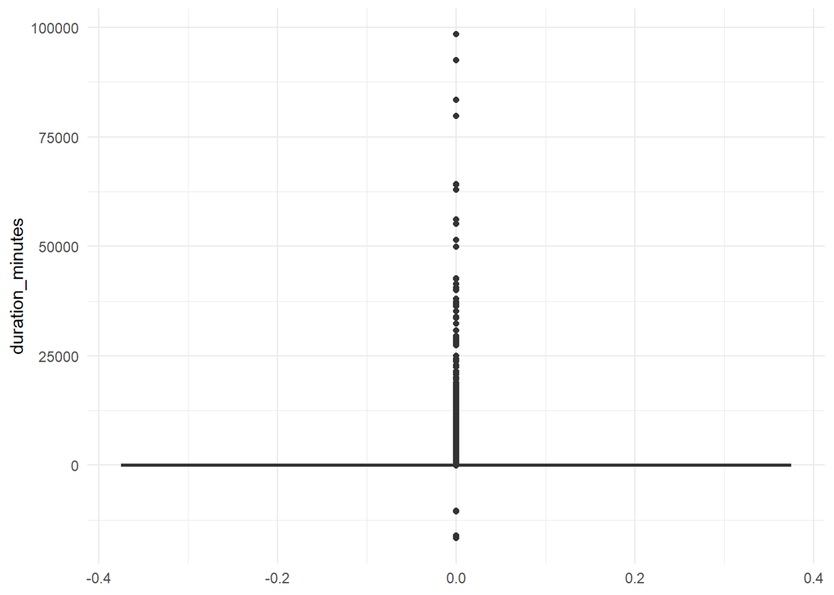

[output not shown]

[output not shown]

[output cut: 630 more lines]

```r
library(gridExtra)

# Create a box plot

ggplot(merged_data, aes(y = duration_minutes)) +
  geom_boxplot() +
  labs(y = "duration_minutes") +
    theme_minimal()
```

I see some data points under 0. possibly because the start and end time have been switched accidentally. So an easy approach is to switch their sign or remove them. I prefer to keep them because every data point is valuable.

[figure not shown]

```r
# Switch the sign of duration_minutes for negative values
merged_data$duration_minutes[merged_data$duration_minutes < 0] <- -merged_data$duration_minutes[merged_data$duration_minutes < 0]
```

#### **trip_length_km**

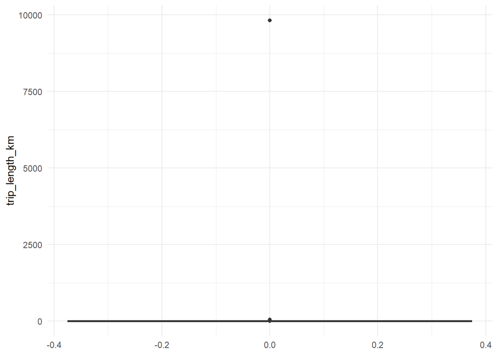

```r
# Create a box plot
ggplot(merged_data, aes_string(y = "trip_length_km")) +
  geom_boxplot() +
  labs(y = "trip_length_km") +
    theme_minimal()
```

Some of the data points has a very long trip length (about 10000)

```r
# Find rows with trip_length_km greater than a threshold (e.g., 100 km)
outliers <- merged_data$trip_length_km > 100

merged_data[outliers, ]
```

```
##                  ride_id rideable_type          started_at            ended_at
## 2149866 873D50153BBC0686 electric_bike 2023-06-15 12:38:05 2023-06-15 12:38:41
## 2159177 ADFF57D27B5BF9D2  classic_bike 2023-06-15 09:38:07 2023-06-15 09:42:57
## 3413676 43107577DF9B498D  classic_bike 2023-08-21 18:43:22 2023-08-21 22:05:55
##             start_station_name       start_station_id
## 2149866 OH Charging Stx - Test OH Charging Stx - Test
## 2159177     State St & 54th St                    646
## 3413676  Dearborn St & Erie St                  13045
##                   end_station_name         end_station_id start_lat start_lng
## 2149866     OH Charging Stx - Test OH Charging Stx - Test  41.86317 -87.67981
## 2159177     OH Charging Stx - Test OH Charging Stx - Test  41.79664 -87.62592
## 3413676 Stony Island Ave & 63rd St                   653B  41.89399 -87.62932
##         end_lat end_lng member_casual duration_minutes hour day_of_week
## 2149866       0       0        member                1   12         Thu
## 2159177       0       0        casual                5    9         Thu
## 3413676       0       0        casual              203   18         Mon
##         day_of_month trip_length_km month trip_ID
## 2149866           15       9826.424   Jun 2149866
## 2159177           15       9821.754   Jun 2159177
## 3413676           21       9822.335   Aug 3413676
```

The reason of these very long trip length is that the trip destination **end_lng** and **end_lat** are wrongly entered as zeros. This point is known as Null Island which is located in the Gulf of Guinea, making the calculated distance very long.  
A reasonable approach is to calculate the average end_lat and end_lng for each end_station_name, then join these averages with the original data based on the station name. Finally, replaces the zeros in end_lat and end_lng with the corresponding averages.

```r
# Calculate the average end_lat and end_lng for each end_station_name
station_averages <- merged_data %>%
  filter(end_lat != 0 & end_lng != 0) %>%  # Exclude rows with zeros
  group_by(end_station_name) %>%
  summarize(avg_end_lat = mean(end_lat),
            avg_end_lng = mean(end_lng))

# Join the average values with the original data and replace zeros with averages
merged_data <- merged_data %>%
  left_join(station_averages, by = "end_station_name") %>%
  mutate(end_lat = ifelse(end_lat == 0, avg_end_lat, end_lat),
         end_lng = ifelse(end_lng == 0, avg_end_lng, end_lng)) %>%
  select(-avg_end_lat, -avg_end_lng)  # Remove the temporary columns

# Check if zeros are replaced
summary(merged_data$end_lat)
```

```
##    Min. 1st Qu.  Median    Mean 3rd Qu.    Max.
##   41.61   41.88   41.90   41.90   41.93   42.18
```

```r
summary(merged_data$end_lng)
```

```
##    Min. 1st Qu.  Median    Mean 3rd Qu.    Max.
##  -88.16  -87.66  -87.64  -87.65  -87.63  -87.33
```

Let’s recalculate the trip_length_km with the most recent changes

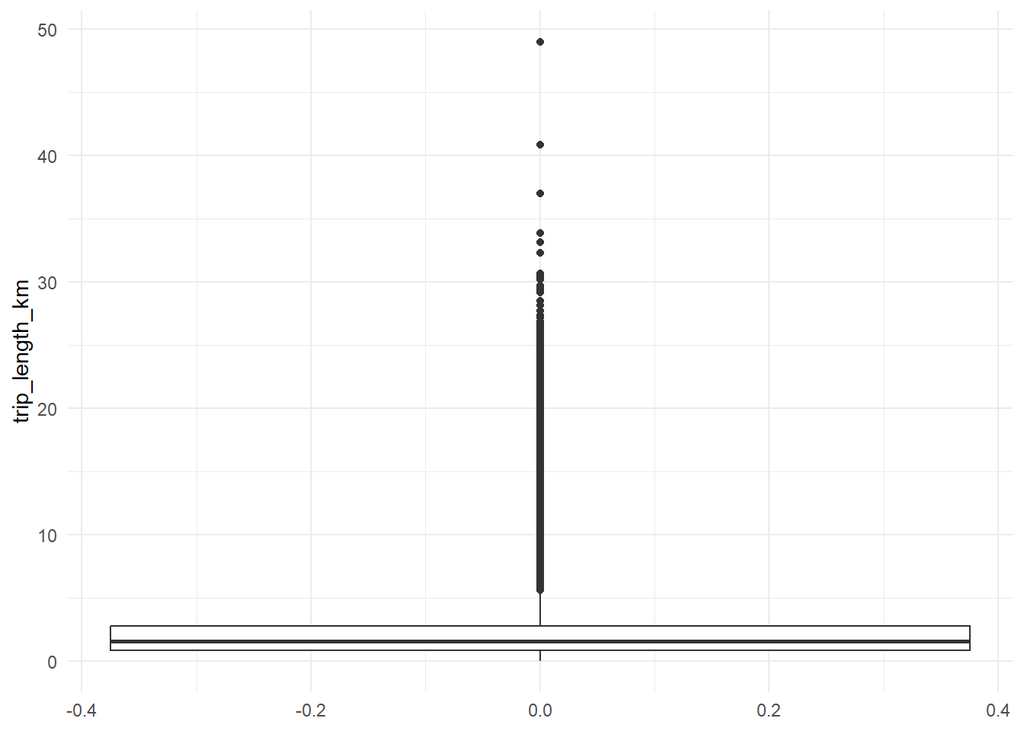

```r
# recalcultes the trip_length_km
merged_data$trip_length_km <- geosphere::distHaversine(
  cbind(merged_data$start_lng, merged_data$start_lat),
  cbind(merged_data$end_lng, merged_data$end_lat)
) / 1000

# Create a box plot
ggplot(merged_data, aes_string(y = "trip_length_km")) +
  geom_boxplot() +
  labs(y = "trip_length_km") +
    theme_minimal()
```

### Features Engineering V2

At last, I removed all the unnecessary features, keeping only those are relevant the the business task including:

trip_Id, rideable_type, member_casual, duration_minutes, hour, day_of_week, day of month, month, trip_length_km.

Doing so will reduce our data frame size making the analysis process much faster and reduce lags and waiting time.

```r
merged_data <- merged_data[, c("trip_ID", "rideable_type", "member_casual", "duration_minutes", "hour", "day_of_week", "day_of_month", "month", "trip_length_km")]
head(merged_data)
```

```
##   trip_ID rideable_type member_casual duration_minutes hour day_of_week
## 1       1 electric_bike        member               11   20         Sat
## 2       2  classic_bike        member                8   15         Tue
## 3       3 electric_bike        casual               13    7         Mon
## 4       4  classic_bike        member                9   10         Sun
## 5       5  classic_bike        member               15   13         Thu
## 6       6 electric_bike        member                3    7         Tue
##   day_of_month month trip_length_km
## 1           21   Jan      0.8399817
## 2           10   Jan      1.2059229
## 3            2   Jan      3.5476523
## 4           22   Jan      1.2059229
## 5           12   Jan      1.2059229
## 6           31   Jan      0.4477086
```

# Analyse - Analysis, Visualizations, and Key Findings

Presenting supporting visualizations that aid in understanding the data, accompanied by key findings derived from the analysis.

```r
glimpse(merged_data)
```

```
## Rows: 5,719,877
## Columns: 9
## $ trip_ID          <int> 1, 2, 3, 4, 5, 6, 7, 8, 9, 10, 11, 12, 13, 14, 15, 16…
## $ rideable_type    <chr> "electric_bike", "classic_bike", "electric_bike", "cl…
## $ member_casual    <fct> member, member, casual, member, member, member, membe…
## $ duration_minutes <dbl> 11, 8, 13, 9, 15, 3, 14, 9, 12, 13, 10, 9, 8, 10, 5, …
## $ hour             <int> 20, 15, 7, 10, 13, 7, 21, 10, 20, 16, 17, 17, 19, 20,…
## $ day_of_week      <ord> Sat, Tue, Mon, Sun, Thu, Tue, Sun, Wed, Wed, Fri, Thu…
## $ day_of_month     <int> 21, 10, 2, 22, 12, 31, 15, 25, 25, 6, 5, 3, 9, 3, 12,…
## $ month            <ord> Jan, Jan, Jan, Jan, Jan, Jan, Jan, Jan, Jan, Jan, Jan…
## $ trip_length_km   <dbl> 0.8399817, 1.2059229, 3.5476523, 1.2059229, 1.2059229…
```

## **Approach: Leveraging Total and Average Metrics**

In my quest to differentiate between member and casual users, I have adopted a comprehensive approach by utilizing a combination of total, average, and count metrics. This strategic choice enables me to gain a nuanced understanding of various aspects of user behavior, ensuring a well-rounded analysis.

**Total Metrics: Capturing Magnitude and Impact**

The inclusion of total metrics, such as the total number of trips or total distance covered, allows us to comprehend the overall magnitude and cumulative impact of user activity. This approach provides insights into the absolute contribution of each user type, aiding in the assessment of their respective scales of engagement with the bike-sharing service.

**Average Metrics: Unveiling Typical Behavior**

Concurrently, we employ average metrics, such as average trip duration or average distance per trip, to reveal the typical behavior exhibited by each user type. Calculating averages normalizes the data, providing a balanced perspective that considers variations in dataset sizes. This is particularly valuable for understanding the standard or average experience of users, irrespective of the overall volume of their activity.

**Count Metrics: Quantifying Frequency**

In addition to total and average metrics, we incorporate count metrics to quantify the frequency of user interactions. Counting the number of trips or occurrences provides a straightforward measure of user engagement, complementing the insights derived from total and average metrics.

By strategically combining total, average, and count metrics, our analysis aims to uncover patterns, preferences, and distinctions between member and casual users. This multifaceted approach ensures a comprehensive exploration of user behavior, empowering us to address the overarching business question: “How do member and casual users differ in their utilization of our bike-sharing service?”

## Note About the used Features

```r
skimr::skim_without_charts(merged_data)
```

Data summary

| Name | merged_data |
| --- | --- |
| Number of rows | 5719877 |
| Number of columns | 9 |
| _______________________ |  |
| Column type frequency: |  |
| character | 1 |
| factor | 3 |
| numeric | 5 |
| ________________________ |  |
| Group variables | None |

**Variable type: character**

| skim_variable | n_missing | complete_rate | min | max | empty | n_unique | whitespace |
| --- | --- | --- | --- | --- | --- | --- | --- |
| rideable_type | 0 | 1 | 11 | 13 | 0 | 3 | 0 |

**Variable type: factor**

| skim_variable | n_missing | complete_rate | ordered | n_unique | top_counts |
| --- | --- | --- | --- | --- | --- |
| member_casual | 0 | 1 | FALSE | 2 | mem: 3660698, cas: 2059179 |
| day_of_week | 0 | 1 | TRUE | 7 | Sat: 883566, Thu: 860202, Fri: 843524, Wed: 835625 |
| month | 0 | 1 | TRUE | 12 | Aug: 771693, Jul: 767650, Jun: 719618, Sep: 666371 |

**Variable type: numeric**

| skim_variable | n_missing | complete_rate | mean | sd | p0 | p25 | p50 | p75 | p100 |
| --- | --- | --- | --- | --- | --- | --- | --- | --- | --- |
| trip_ID | 0 | 1 | 2859939.00 | 1651186.41 | 1 | 1429970.00 | 2859939.00 | 4289908.00 | 5719877.00 |
| duration_minutes | 0 | 1 | 18.20 | 180.84 | 0 | 5.00 | 10.00 | 17.00 | 98489.00 |
| hour | 0 | 1 | 14.09 | 4.94 | 0 | 11.00 | 15.00 | 18.00 | 23.00 |
| day_of_month | 0 | 1 | 15.54 | 8.74 | 1 | 8.00 | 15.00 | 23.00 | 31.00 |
| trip_length_km | 0 | 1 | 2.10 | 1.91 | 0 | 0.86 | 1.54 | 2.76 | 48.98 |

The final data has these features:

1. **Numerical:** duration_minutes, trip_length_km
2. **Categorical:** trip_IDraidable_type, member_casual, hour, day, weekday, month

All the categorical time features(hour, day, weekday, month) are extracted from the started_at datetime feature. And the reason why I chose this one over the ended_at is that we only interested in the time that each trip started.

The calculated trip_length_km feature is the result of measuring the distance between the start and the end coordinates of each trip, but that doesn’t mean that this is the real trip length because if someone starts and finish the trip in the same location taking an hour in total, it doesn’t mean the trip length is 0!!!, so the other factor that needs to be ware of is the duration_minutes

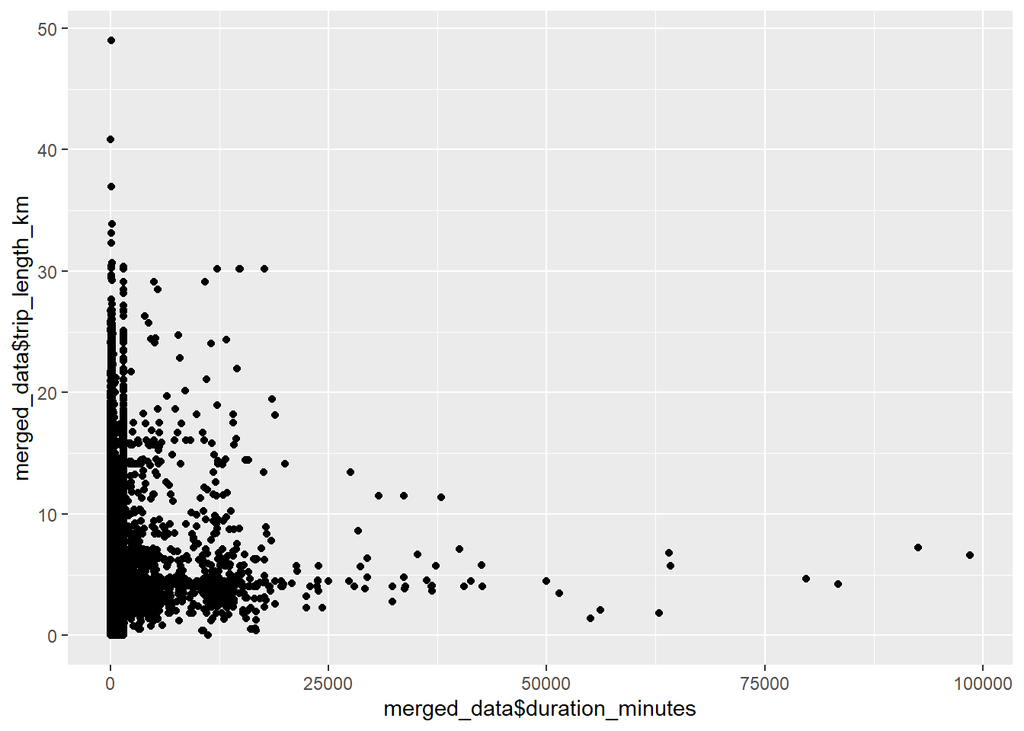

```r
ggplot(merged_data) + geom_point(mapping = aes(x=merged_data$duration_minutes, y=merged_data$trip_length_km))
```

Over all, the trip_length_km is a good indecator that may gives us some hints about the difference between the casual users and the annual members

## **Frequency of Trip Booking:**

Q: How frequently do members and casual users book trips?

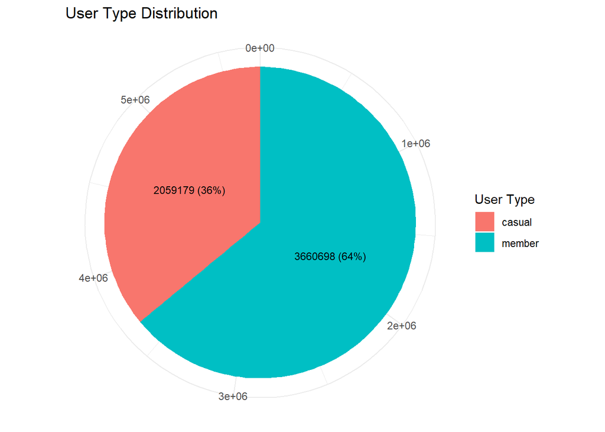

## **Bike Type Usage:**

Q: How does each user type use different bike types for their trips?

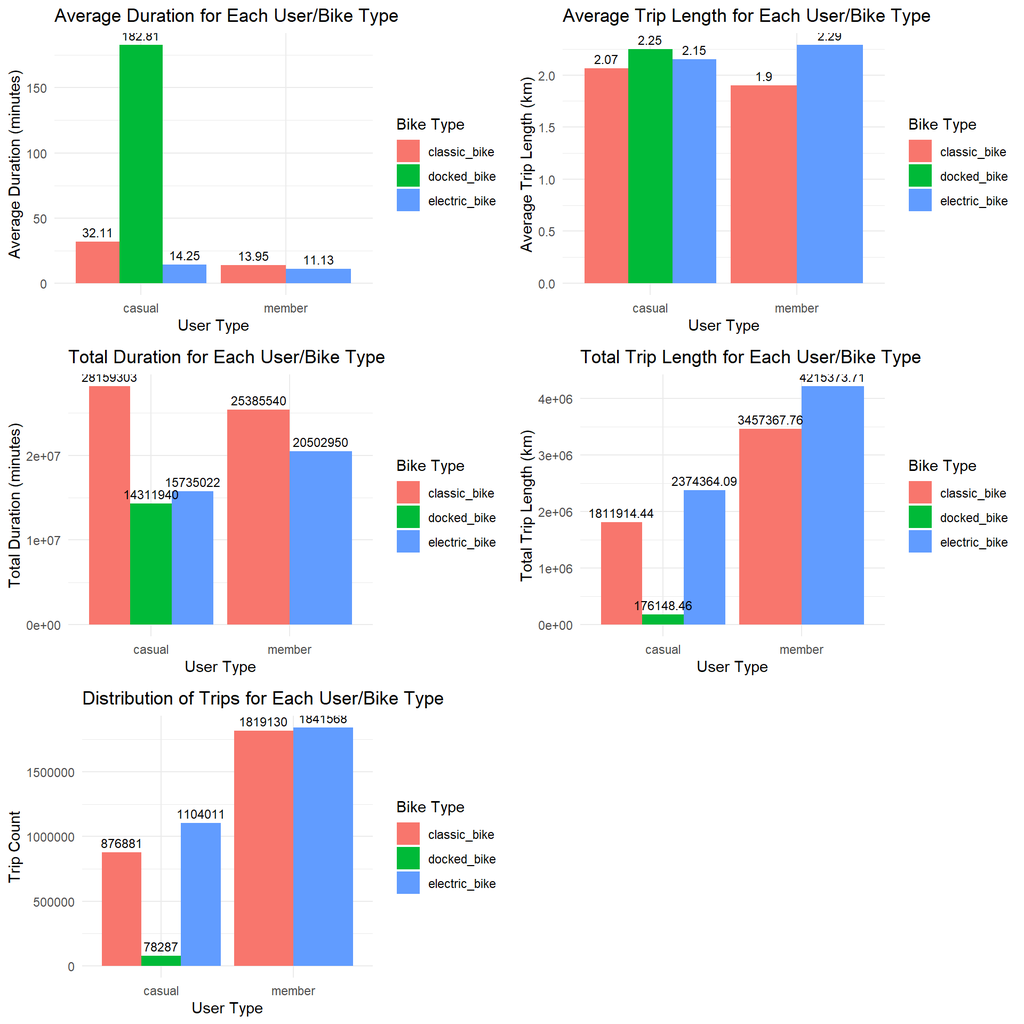